# Advanced Empirical Finance: Topics and Data Science

Latent factors

Stefan Voigt

University of Copenhagen and Danish Finance Institute (DFI)

Spring 2027

## Today

- Your validation schemes
- Principal components of the factor zoo
- Variance is not a premium: risk-premium PCA
- How many factors?

## From 158 anomalies to a few factors

**Today:** which few factors? The ones that explain the most variance, or the ones that carry a premium?

# Your validation schemes

## How much does the validation scheme matter?

# Principal components

## Whiteboard: principal component analysis

Find the portfolio $w$ of the anomalies with the largest variance, $\max_w w'\Sigma w$ subject to $w'w = 1$. Then the next one, uncorrelated with the first

$$\Sigma w = \delta\, w \qquad \Longrightarrow \qquad \Sigma = \sum_j \delta_j\, v_j v_j'$$

- The principal components are the eigenvectors $v_j$ of $\Sigma$, sorted by their eigenvalues $\delta_j$, the variances of the factors $f_{j,t} = v_j' F_t$
- The first $k$ components explain the most variance that any $k$ factors can: the best factor model in the least-squares sense

## Principal components in code

- R
- Python

```r
# Mean-variance weights on the first k eigenvectors of the covariance
# matrix plus phi times the outer product of the means (phi = 0: PCA)
factor_weights <- function(x, k, phi = 0) {
  mu <- colMeans(x)
  loadings <- eigen(cov(x) + phi * tcrossprod(mu), symmetric = TRUE)$vectors[, seq_len(k), drop = FALSE]
  factors <- x %*% loadings
  loadings %*% solve(cov(factors), colMeans(factors))
}
```

```python
# Mean-variance weights on the first k eigenvectors of the covariance
# matrix plus phi times the outer product of the means (phi = 0: PCA)
def factor_weights(x, k, phi=0.0):
    mu = x.mean(axis=0)
    values, vectors = np.linalg.eigh(np.cov(x, rowvar=False) + phi * np.outer(mu, mu))
    loadings = vectors[:, np.argsort(values)[::-1][:k]]
    factors = x @ loadings
    covariance = np.atleast_2d(np.cov(factors, rowvar=False))
    return loadings @ np.linalg.solve(covariance, factors.mean(axis=0))
```

The factors are portfolios of the anomalies; their mean-variance portfolio is again a portfolio of the anomalies, so `portfolio_sharpe()` of lecture 10 evaluates it

## Variance is not a premium

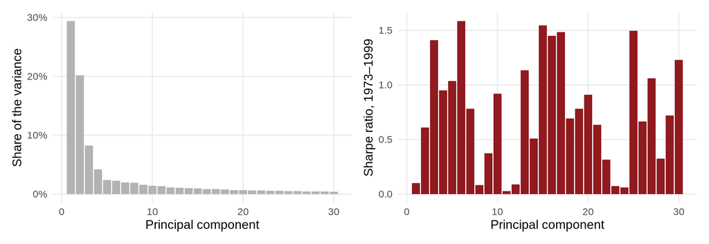

- The first component explains 29% of the variance, but its Sharpe ratio is only 0.10. Components further down carry the premia
- Mean-variance portfolio of the first 1, 5 and 20 components in the test sample: -0.03, 0.70 and 1.71

# Risk-premium PCA

## Whiteboard: risk-premium PCA

Lettau & Pelger (2020): choose the factors so that they explain the variances **and** the means of the anomalies

$$\text{eigenvectors of} \quad \Sigma + \varphi\, \mu\mu'$$

- $\varphi = 0$: PCA. $\varphi > 0$: directions in which the anomalies have large means count more, so factors with a premium move up the ranking
- The factors still explain the comovement: a compromise between a factor model and the SDF
- In the code, `factor_weights(x, k, phi)` with $\varphi$ = 10, a weight of the size Lettau & Pelger use

## Risk-premium PCA on the zoo

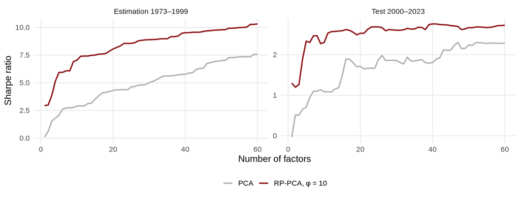

- With a weight on the means, one factor reaches 1.30 in the test sample (PCA: -0.03), five reach 2.34 (PCA: 0.70)
- With many factors the gap narrows, since both span more and more of the same space: at 60 factors, 2.29 against 2.73

## How many factors?

- R
- Python

```r
# The number of factors is a tuning parameter: cross-validation as in lecture 11
factor_cv <- expand_grid(phi = c(0, phi_rp), factors = seq_len(max_factors)) |>
  mutate(cv = map2_dbl(phi, factors, \(phi, k) cv_sharpe(\(x, k) factor_weights(x, k, phi), k)))
```

```python
# The number of factors is a tuning parameter: cross-validation as in lecture 11
factor_cv = {(phi, k): cv_sharpe(lambda x, k: factor_weights(x, k, phi), k)
             for phi in [0, 10] for k in range(1, 61)}
```

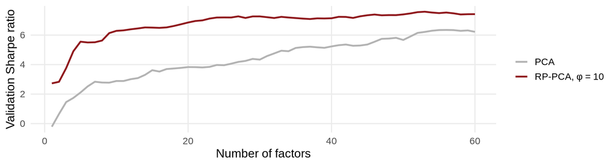

## Outlook: loadings from characteristics

- PCA treats the loadings $\Lambda$ as constant. But a stock’s exposure changes with its size, value or momentum
- **Instrumented PCA** (Kelly, Pruitt & Su, 2019): loadings are functions of characteristics, $\beta_{i,t} = z_{i,t}'\Gamma$, and the factors stay latent. A handful of such factors prices the cross-section of individual stocks
- **Lecture 14:** a neural network lets the SDF weights depend on characteristics in any shape

## Scoreboard

| Portfolio | Inputs | Sharpe ratio 1973–1999 | Sharpe ratio 2000–2023 |
| --- | --- | --- | --- |
| Market | Market | 0.47 | 0.42 |
| Plug-in mean-variance | 158 anomalies | 15.72 | 2.51 |
| Ridge (prior on Sharpe ratios) | 158 anomalies | 12.92 | 2.89 |
| PCA | 5 factors | 2.09 | 0.70 |
| PCA | 20 factors | 4.32 | 1.71 |
| RP-PCA, φ = 10 | 5 factors | 5.93 | 2.34 |
| RP-PCA, φ = 10 | 20 factors | 8.06 | 2.53 |

- The few-factor models at 5 and 20 factors, since cross-validation does not stop; the rows of lectures 10 and 11 not shown here stay on the scoreboard

Assignment 2 on machine learning in asset pricing starts today